# Juntar R y Python con RStudio

Ramon Ceballos

11/2/2021

# **A. Pokemon (Py -> R)**

## 1. Generalidades para el uso inicial de Python en R

Para poder trabajar con R y Python se emplea la librería “reticulate”.

Para ver que versión de Python se está utilizando, pon en la consola “Sys.which(”python“)” y te indicará el directorio de uso. Si quisiera emplear Python de anaconda u otra versión tendrá que especificar en la primer chunk del RMarkdown la expresión “use_python”(“directorio/ananconda3/bin/python”).

```python
#Para ver si funciona
import pandas as pd
```

Ahora vamos a llamar a Python desde R para lo cuál empleamos “py()” de reticulate.

## 2. Carga de dataset de Pokemon y modelado del dataset (selección) en Python

Cargamos el csv de pokemon con pd.read_csv de pandas. Exploramos si se ha cargado bien el dataset.

Vamos a filtrar el dataset con la siguiente chunk.

Vamos a filtrar por los pokemon de la primera generación y luego con las columnas Type 1, Type 2 y Speed.

Limpiamos los Na con la función de python dropna().

```python
pokemon = pd.read_csv("../../../data/Pokemon.csv")
print(pokemon.shape)
```

```
## (800, 12)
```

```python
print(pokemon.head (4))
```

```
##                     Name Type 1  Type 2  Total  HP  Attack  Defense  Sp_Atk  \
## 0              Bulbasaur  Grass  Poison    318  45      49       49      65
## 1                Ivysaur  Grass  Poison    405  60      62       63      80
## 2               Venusaur  Grass  Poison    525  80      82       83     100
## 3  VenusaurMega Venusaur  Grass  Poison    625  80     100      123     122
##
##    Sp_Def  Speed  Generation  Legendary
## 0      65     45           1      False
## 1      80     60           1      False
## 2     100     80           1      False
## 3     120     80           1      False
```

```python
pokemon = pokemon[pokemon['Generation'] == 1]
print(pokemon.shape)
```

```
## (166, 12)
```

```python
pokemon = pokemon [["Type 1", "Type 2", "Speed"]]
print(pokemon.shape)
```

```
## (166, 3)
```

```python
pokemon = pokemon.dropna()
print(pokemon.shape)
```

```
## (78, 3)
```

## 3. Representar gráficas de los datos de Python en R

Accedemos desde R a la variable creada en python empleando la expresión “py$objeto_python”.

Representamos con un histograma de R la columna de “Speed” de pokemon.

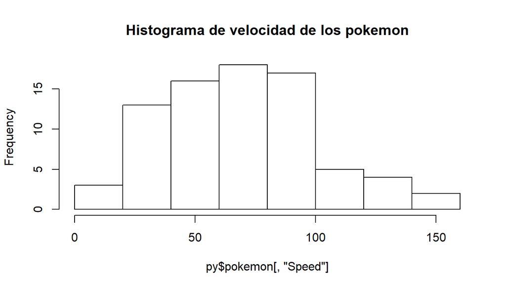

```r
hist(py$pokemon[,"Speed"],
     breaks=9,
     main="Histograma de velocidad de los pokemon")
```

# **B. Pokemon (R -> Py)**

## 1. Carga de dataset de Pokemon y modelado del dataset (selección) en R

Ahora vamos a importar datos en R y representaremos dichos datos a través de Python (lo contrario al apartado A).

```r
pokemon2 <- read.csv("../../../data/Pokemon.csv", header=TRUE)

#Cargamos libreria tidyverse
library(tidyverse)
#Filtramos el dataset
pokemon2 <- pokemon2 %>%
  #Filtro
  filter(Generation==1) %>%
  #Selecciono las columnas
  select(Type.1, Type.2, Speed) %>%
  #Quito los NA
  na.omit()

#Ver estadísticos de cada variable
summary(pokemon2)
```

```
##      Type.1       Type.2       Speed
##  Water  :31          :88   Min.   : 15.00
##  Normal :24   Flying :23   1st Qu.: 50.00
##  Bug    :14   Poison :22   Median : 70.00
##  Fire   :14   Psychic: 7   Mean   : 72.58
##  Poison :14   Ground : 6   3rd Qu.: 92.25
##  Grass  :13   Water  : 4   Max.   :150.00
##  (Other):56   (Other):16
```

Transmitir datos de R a Python con la expresión “r.dataset_R”.

```python
print(r.pokemon2.head())
```

```
##   Type.1  Type.2  Speed
## 0  Grass  Poison     45
## 1  Grass  Poison     60
## 2  Grass  Poison     80
## 3  Grass  Poison     80
## 4   Fire             65
```